# Multiple Imputation with the “mice” Package

## Preface

### R packages

In this practical, a number of R packages are used. The packages used (with versions that were used to generate the solutions) are:

- R version 3.6.1 (2019-07-05)
- `mice` (version: 3.6.0)
- (not essential) `JointAI` (version: 0.6.0)

### Dataset

For this practical, we will use the **NHANES2** dataset, a subset of the data we have seen in the lecture slides.

To load this dataset, you can use the command `file.choose()` which opens the explorer and allows you to navigate to the location of the file `NHANES2_for_practicals.RData` on your computer. If you know the path to the file, you can also use `load("<path>/NHANES2_for_practicals.RData")`. RStudio users can also just click on the file in the “Files” pane/tab to load it.

## Preparing for imputation

### Set-up run

Imputation needs to be tailored to the dataset at hand and, hence, using the function `mice()` well requires several arguments to be specified. To make the specification easier it is useful to do a dry-run which will create the default versions of everything that needs to be specified.

These default settings can then be adapted to our data.

#### Task

Do the set-up run of `mice()` with the NHANES2 data without any iterations (`maxit = 0`).

#### Solution

```r
# Note: This command will not produce any output.
library(mice)
imp0 <- mice(NHANES2, maxit = 0)
```

### Imputation method

There are many imputation methods available in **mice**. You can find the list in the help page of the [`mice()` function](https://www.rdocumentation.org/packages/mice/topics/mice). We will focus here on the following ones:

| name | variable type | description |
| --- | --- | --- |
| pmm | any | Predictive mean matching |
| norm | numeric | Bayesian linear regression |
| logreg | binary | Logistic regression |
| polr | ordered | Proportional odds model |
| polyreg | unordered | Polytomous logistic regression |

The default imputation methods that `mice()` selects can be specified in the argument `defaultMethod`.

If unspecified, `mice` will use

- `pmm` for numerical columns,
- `logreg` for factor columns with two categories,
- `polyreg` for columns with unordered and
- `polr` for columns with ordered factors with more than two categories.

In the `NHANES2` data we have the following variables:

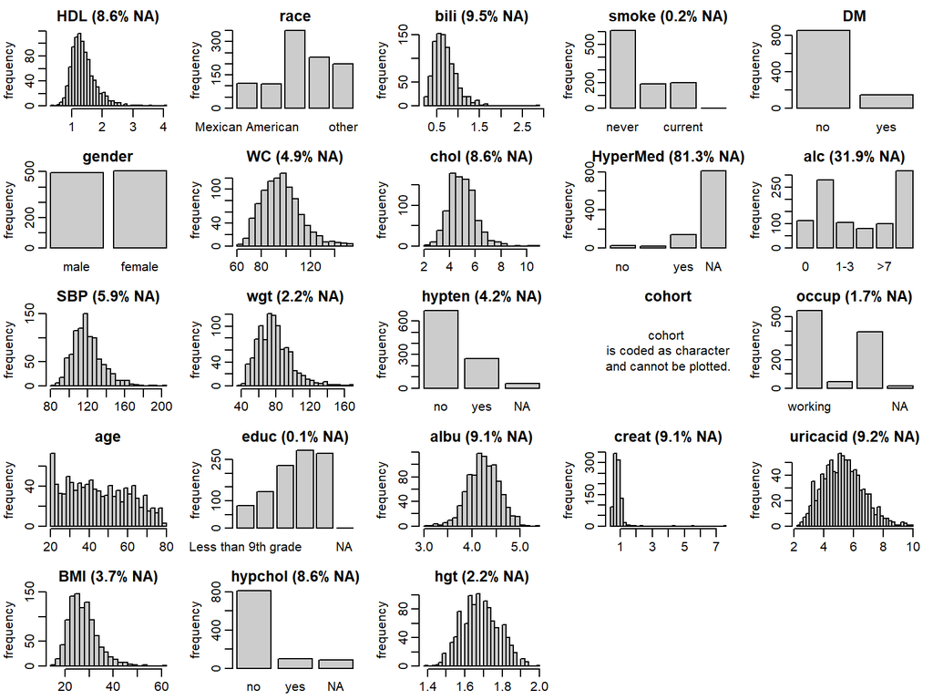

```r
par(mar = c(2,3,2,1), mgp = c(2, 0.6, 0))
JointAI::plot_all(NHANES2, nclass = 30)
```

#### Task 1

When a normal imputation model seems to be appropriate for most of the continuous covariates, you may want to specify `norm` as the default method in the setup run. Let’s do that:

The order of the types of variable is: continuous, binary, factor, ordered factor.

#### Solution 1

```r
imp0 <- mice(NHANES2, maxit = 0,
             defaultMethod = c("norm", 'logreg', 'polyreg', 'polr'))
```

#### Task 2

In the plot of the `NHANES2` data shown above we can see that the variable `creat` has a skewed distribution, hence, using a normal imputation model may not work well.

- Extract the default settings of `meth` from `imp0`.
- Change the imputation method for `creat` so that this variable will be imputed using predictive mean matching.
- Check that all specified imputation methods are correct. When no imputation method is specified (`""`) the variable will not be imputed.

#### Solution 2

```r
meth <- imp0$meth
meth["creat"] <- "pmm"
meth
```

```
##       HDL      race      bili     smoke        DM    gender        WC      chol  HyperMed       alc
##    "norm"        ""    "norm"    "polr"        ""        ""    "norm"    "norm"    "polr"    "polr"
##       SBP       wgt    hypten    cohort     occup       age      educ      albu     creat  uricacid
##    "norm"    "norm"  "logreg"        "" "polyreg"        ""    "polr"    "norm"     "pmm"    "norm"
##       BMI   hypchol       hgt
##    "norm"  "logreg"    "norm"
```

### Predictor matrix

The predictor matrix specifies which variables are used in the linear predictors of each of the imputation models.

A value of `1` specifies that the variable given in the column name is used in the model to impute the variable given in the row name (and `0` specifies that this variable is not used in that model).

#### Task 1

Get the `predictorMatrix` from `imp0`. Notice that **mice** has already set some of the values to `0`. Do you understand why?

#### Solution 1

```r
pred <- imp0$predictorMatrix
pred
```

```
##          HDL race bili smoke DM gender WC chol HyperMed alc SBP wgt hypten cohort occup age educ
## HDL        0    1    1     1  1      1  1    1        1   1   1   1      1      0     1   1    1
## race       1    0    1     1  1      1  1    1        1   1   1   1      1      0     1   1    1
## bili       1    1    0     1  1      1  1    1        1   1   1   1      1      0     1   1    1
## smoke      1    1    1     0  1      1  1    1        1   1   1   1      1      0     1   1    1
## DM         1    1    1     1  0      1  1    1        1   1   1   1      1      0     1   1    1
## gender     1    1    1     1  1      0  1    1        1   1   1   1      1      0     1   1    1
## WC         1    1    1     1  1      1  0    1        1   1   1   1      1      0     1   1    1
## chol       1    1    1     1  1      1  1    0        1   1   1   1      1      0     1   1    1
## HyperMed   1    1    1     1  1      1  1    1        0   1   1   1      1      0     1   1    1
## alc        1    1    1     1  1      1  1    1        1   0   1   1      1      0     1   1    1
## SBP        1    1    1     1  1      1  1    1        1   1   0   1      1      0     1   1    1
## wgt        1    1    1     1  1      1  1    1        1   1   1   0      1      0     1   1    1
## hypten     1    1    1     1  1      1  1    1        1   1   1   1      0      0     1   1    1
## cohort     1    1    1     1  1      1  1    1        1   1   1   1      1      0     1   1    1
## occup      1    1    1     1  1      1  1    1        1   1   1   1      1      0     0   1    1
## age        1    1    1     1  1      1  1    1        1   1   1   1      1      0     1   0    1
## educ       1    1    1     1  1      1  1    1        1   1   1   1      1      0     1   1    0
## albu       1    1    1     1  1      1  1    1        1   1   1   1      1      0     1   1    1
## creat      1    1    1     1  1      1  1    1        1   1   1   1      1      0     1   1    1
## uricacid   1    1    1     1  1      1  1    1        1   1   1   1      1      0     1   1    1
## BMI        1    1    1     1  1      1  1    1        1   1   1   1      1      0     1   1    1
## hypchol    1    1    1     1  1      1  1    1        1   1   1   1      1      0     1   1    1
## hgt        1    1    1     1  1      1  1    1        1   1   1   1      1      0     1   1    1
##          albu creat uricacid BMI hypchol hgt
## HDL         1     1        1   1       1   1
## race        1     1        1   1       1   1
## bili        1     1        1   1       1   1
## smoke       1     1        1   1       1   1
## DM          1     1        1   1       1   1
## gender      1     1        1   1       1   1
## WC          1     1        1   1       1   1
## chol        1     1        1   1       1   1
## HyperMed    1     1        1   1       1   1
## alc         1     1        1   1       1   1
## SBP         1     1        1   1       1   1
## wgt         1     1        1   1       1   1
## hypten      1     1        1   1       1   1
## cohort      1     1        1   1       1   1
## occup       1     1        1   1       1   1
## age         1     1        1   1       1   1
## educ        1     1        1   1       1   1
## albu        0     1        1   1       1   1
## creat       1     0        1   1       1   1
## uricacid    1     1        0   1       1   1
## BMI         1     1        1   0       1   1
## hypchol     1     1        1   1       0   1
## hgt         1     1        1   1       1   0
```

#### Task 2

Because BMI is calculated from height (`hgt`) and weight (`wgt`), and there are cases where only one of these two variables is missing, we want to impute `hgt` and `wgt` separately. `BMI` should be imputed using *passive imputation*.

To avoid multicollinearity (which may lead to problems during imputation), imputation models should not include all three variables as predictor variables. In this example, we will use `BMI` to impute the other variables.

Moreover, we need to exclude waist circumference (`WC`) from the imputation model for `wgt` because the high correlation between `WC`, `BMI` and `wgt` would otherwise lead to problems during imputation. (In practie you would first try to leave it in and only exclude it if it causes problems.)

And since `HyperMed` does not give us a lot more information than `hypten`, but has a lot more missing values, we do not want to use it as a predictor variable.

Apply the necessary changes to `pred` and `meth`.

For passive imputation, you need to specify the formula used to calculate BMI in meth using `"~I(...)"`.

#### Solution 2

```r
# BMI will not be used as predictor of height and weight
pred[c("hgt", "wgt"), "BMI"] <- 0
# height and weight will not be used as predictor in any model
pred[, c("hgt", "wgt")] <- 0
# height and weight will be used as predictors for each other
pred["hgt", "wgt"] <- 1
pred["wgt", "hgt"] <- 1

# WC is not used as predictor for weight
pred["wgt", "WC"] <- 0

# HyperMed will not be used as predictor in any model
pred[, "HyperMed"] <- 0

# hypchol will not be used as predictor in the imputation model for chol
pred["chol", "hypchol"] <- 0

# BMI will be imputed passively
meth["BMI"] <- "~I(wgt/hgt^2)"
# HyperMed will not be imputed
meth["HyperMed"] <- ""
```

### Visit sequence

The visit sequence specifies the order in which the variables are imputed.

#### Task

To be sure that the imputed values of `BMI` match the imputed values of `hgt` and `wgt`, `BMI` needs to be imputed after `hgt` and `wgt`.

- Get the `visitSequence` from `imp0`, and
- change it if necessary.

#### Solution

```r
visSeq <- imp0$visitSequence
visSeq
```

```
##  [1] "HDL"      "race"     "bili"     "smoke"    "DM"       "gender"   "WC"       "chol"
##  [9] "HyperMed" "alc"      "SBP"      "wgt"      "hypten"   "cohort"   "occup"    "age"
## [17] "educ"     "albu"     "creat"    "uricacid" "BMI"      "hypchol"  "hgt"
```

```r
# find "BMI" in the visit sequence
which_BMI <- match("BMI", visSeq)
# move "BMI" to the end of the sequence
visSeq <- c(visSeq[-which_BMI], visSeq[which_BMI])
```

## Imputation

### Running the imputation

#### Task

With the changes that we have made to the `predictorMatrix`, `method` and `visitSequence`, we can now perform the imputation. For now, use no more then `m = 5` and `maxit = 10` (to save some time).

#### Solution

```r
imp <- mice(NHANES2, method = meth, predictorMatrix = pred, visitSequence = visSeq,
            maxit = 10, m = 5, seed = 2019)
```

`mice()` prints the name of the variable being imputed for each iteration and imputation. If you run `mice()` on your own computer the output will show up continuously. There, you may notice that imputation is slowest for categorical variables, especially when they have many categories.

You can hide the lengthy output by specifying `printFlag = FALSE`.

### What does mice return?

#### Task

`mice()` does not return a `data.frame`. Find out the class of the object returned by `mice()` function using the function `class()` and `names()`, and take a look at the [help file](https://www.rdocumentation.org/packages/mice/versions/2.46.0/topics/mids-class) for this class.

#### Solution

```r
class(imp)
```

```
## [1] "mids"
```

```r
names(imp)
```

```
##  [1] "data"            "imp"             "m"               "where"           "blocks"
##  [6] "call"            "nmis"            "method"          "predictorMatrix" "visitSequence"
## [11] "formulas"        "post"            "blots"           "seed"            "iteration"
## [16] "lastSeedValue"   "chainMean"       "chainVar"        "loggedEvents"    "version"
## [21] "date"
```

We see that `imp` is an object of class `mids`.

The [help file](https://www.rdocumentation.org/packages/mice/topics/mids-class) tells us that a `mids` object is a list with several elements:

| `data`: | Original (incomplete) data set. |
| --- | --- |
| `imp`: | The imputed values: A list of `ncol(data)` components, each list component is a matrix with `nmis[j]` rows and `m` columns. |
| `m`: | The number of imputations. |
| `where`: | The missingness indicator matrix. |
| `blocks` | The blocks argument of the `mice()` function. |
| `call`: | The call that created the `mids` object. |
| `nmis`: | The number of missing observations per variable. |
| `method`: | The vector imputation methods. |
| `predictorMatrix`: | The predictor matrix. |
| `visitSequence`: | The sequence in which columns are visited during imputation. |
| `formulas` | A named list of formulas corresponding the the imputed variables (blocks). |
| `post`: | A vector of strings of length `length(blocks)` with commands for post-processing. |
| `seed`: | The seed value of the solution. |
| `iteration`: | The number of iterations. |
| `lastSeedValue`: | The most recent seed value. |
| `chainMean:` | The mean of imputed values per variable and iteration: a list of `m` components. Each component is a matrix with `maxit`columns and `length(visitSequence)` rows. |
| `chainVar`: | The variances of imputed values per variable and iteration(same structure as `chainMean`). |
| `loggedEvents`: | A `data.frame` with the record of automatic corrective actions and warnings; (`NULL` if no action was made). |
| `version` | Version number of the **mice** package that created the object. |
| `date` | Date at which the object was created. |

**Details of the `loggedEvents`:**

`mice()` does some pre-processing of the data:

- variables containing missing values, that are not imputed but used as predictor are removed
  - constant variables are removed
  - collinear variables are removed

Furthermore, during each iteration

- variables (or dummy variables) that are linearly dependent are removed
  - `polr` imputation that does not converge is replaced by `polyreg`.

The `data.frame` in `loggedEvents` has the following columns:

| `it` | iteration number |
| --- | --- |
| `im` | imputation number |
| `dep` | name of the name of the variable being imputed |
| `meth` | imputation method used |
| `out` | character vector with names of altered/removed predictors |

© Nicole Erler